# **Social Media Analysis on LinkedIn Premium - Data Exploration, Visualization and Analysis**

**Group 3:** Anh Phuong Ta, Xiaoyu Lyu, Aminaa Tserendagva, Minhua He, Anh Khoa Truong, Ying Cao, Pichsinee Kalklod, Yu Hsuan Wang, Yu Ching Chou, Thi Thuy Khue Nguyen, Kausalya Nandan Kolisetty.

### **INTRODUCTION**

LinkedIn is a social networking platform used by professionals in the business community. The goal of the site is to enable registered members to establish and document networks of people they know and trust professionally. Additionally, LinkedIn serves as a valuable tool for job seekers, company research, and industry news updates. LinkedIn gathers data across users’ profiles to provide employers, workers and educators with data-driven insight into patterns that help align workforce supply with demand worldwide.

### **DATASET DESCRIPTION**

Our team was divided into 2 smaller teams to work on these 2 datasets which aim to look at different types of possible visualizations for not only jobs posted on LinkedIn Premium but also the companies on the platform.

### **PROPOSAL OBJECTIVE**

As mentioned above, we will walk you through all the steps that we took to analyze the two chosen datasets. We will also provide visualizations such as graphs to explain why it is necessary for LinkedIn Premium to implement them.

### **TOOLS USED**

This proposal was completed using Python for all steps, including:

1. Data Exploration
2. Data Preprocessing
3. Data Visualization
4. Data Analysis

### **DATA EXPLORATION - DATASET 1**

We will import all the necessary packages first in Python:

```python
import numpy as np
import pandas as pd
import warnings
import matplotlib.pyplot as plt
warnings.filterwarnings('ignore')
from sklearn.cluster import KMeans
from sklearn.preprocessing import StandardScaler
from sklearn.impute import SimpleImputer
# Import library with built in color palletes
import seaborn as sns
```

```python
# Import the first dataset
dataset1 = pd.read_csv("C:/Users/anhta/OneDrive/Desktop/MSBA 265/Project/job_postings.csv")
```

```python
# Recall the first 5 rows of dataset 1 to check the data
dataset1.head(5)
```

|  | job_id | company_id | title | description | max_salary | med_salary | min_salary | pay_period | formatted_work_type | location | ... | closed_time | formatted_experience_level | skills_desc | listed_time | posting_domain | sponsored | work_type | currency | compensation_type | scraped |
| --- | --- | --- | --- | --- | --- | --- | --- | --- | --- | --- | --- | --- | --- | --- | --- | --- | --- | --- | --- | --- | --- |
| 0 | 3757940104 | 553718.0 | Hearing Care Provider | Overview\n\nHearingLife is a national hearing ... | NaN | 5250.00 | NaN | MONTHLY | Full-time | Little River, SC | ... | NaN | Entry level | NaN | 1.699090e+12 | careers-demant.icims.com | 0 | FULL_TIME | USD | BASE_SALARY | 1699138101 |
| 1 | 3757940025 | 2192142.0 | Shipping & Receiving Associate 2nd shift (Beav... | Metalcraft of Mayville\nMetalcraft of Mayville... | NaN | NaN | NaN | NaN | Full-time | Beaver Dam, WI | ... | NaN | NaN | NaN | 1.699080e+12 | www.click2apply.net | 0 | FULL_TIME | NaN | NaN | 1699085420 |
| 2 | 3757938019 | 474443.0 | Manager, Engineering | \nThe TSUBAKI name is synonymous with excellen... | NaN | NaN | NaN | NaN | Full-time | Bessemer, AL | ... | NaN | NaN | Bachelor's Degree in Mechanical Engineering pr... | 1.699080e+12 | www.click2apply.net | 0 | FULL_TIME | NaN | NaN | 1699085644 |
| 3 | 3757938018 | 18213359.0 | Cook | descriptionTitle\n\n Looking for a great oppor... | NaN | 22.27 | NaN | HOURLY | Full-time | Aliso Viejo, CA | ... | NaN | Entry level | NaN | 1.699080e+12 | jobs.apploi.com | 0 | FULL_TIME | USD | BASE_SALARY | 1699087461 |
| 4 | 3757937095 | 437225.0 | Principal Cloud Security Architect (Remote) | Job Summary\nAt iHerb, we are on a mission to ... | 275834.0 | NaN | 205956.0 | YEARLY | Full-time | United States | ... | NaN | Mid-Senior level | NaN | 1.699090e+12 | careers.iherb.com | 0 | FULL_TIME | USD | BASE_SALARY | 1699085346 |

5 rows × 28 columns

```python
# Next, we are checking the types of each columns
dataset1.info()
```

```
<class 'pandas.core.frame.DataFrame'>
RangeIndex: 33246 entries, 0 to 33245
Data columns (total 28 columns):
 #   Column                      Non-Null Count  Dtype
---  ------                      --------------  -----
 0   job_id                      33246 non-null  int64
 1   company_id                  32592 non-null  float64
 2   title                       33246 non-null  object
 3   description                 33245 non-null  object
 4   max_salary                  11111 non-null  float64
 5   med_salary                  2241 non-null   float64
 6   min_salary                  11111 non-null  float64
 7   pay_period                  13352 non-null  object
 8   formatted_work_type         33246 non-null  object
 9   location                    33246 non-null  object
```

[output cut: 20 more lines]

From the code above, we can also see there are a total of 28 columns with 33,246 entries (rows). However, when we look at non-null count we can see that there are a lot of null values for different columns. We will check these counts with the next code:

```python
dataset1.isnull().sum()
```

```
job_id                            0
company_id                      654
title                             0
description                       1
max_salary                    22135
med_salary                    31005
min_salary                    22135
pay_period                    19894
formatted_work_type               0
location                          0
applies                       17008
original_listed_time              0
remote_allowed                28444
views                          7360
job_posting_url                   0
application_url               12250
application_type                  0
expiry                            0
closed_time                   32074
formatted_experience_level     9181
skills_desc                   32909
listed_time                       0
posting_domain                13558
sponsored                         0
work_type                         0
currency                      19894
compensation_type             19894
scraped                           0
dtype: int64
```

### **DATA PREPROCESSING - DATASET 1**

There are several things we can do with preprocessing, such as data cleaning, update missing data, data transformation, etc. First we will clean the data based on the null values:

```python
# Drop all potential duplicates in the dataset
dataset1 = dataset1.drop_duplicates()

# Drop columns that not sinificanntly relate to analysis
dataset1_new = dataset1.drop(columns=['company_id', 'med_salary', 'closed_time', 'listed_time', 'pay_period', 'skills_desc', 'expiry', 'currency'
                                      , 'compensation_type','scraped', 'posting_domain', 'job_posting_url', 'application_url', 'original_listed_time'])
```

The reason why we drop the following columns in the second code is because our team believe those data do not contribute valuable insights to our analysis. </br> Next, for the column `remote_allowed`, there are 2 main values: NaN and 1, with 1 meaning that the job allows to work remotely. Since we cannot work with NaN values, we will change all NaN to 0 in the following code:

```python
# Fill null values in 'remote_allowed' column with 0
dataset1_new['remote_allowed'].fillna(0, inplace=True)

# Checking the values of remote_allowed column again to confirm the changes
dataset1_new['remote_allowed'].unique()
```

```
array([0., 1.])
```

```python
# Review our dataset 1 after cleaning
dataset1_new.head(5)
```

|  | job_id | title | description | max_salary | min_salary | formatted_work_type | location | applies | remote_allowed | views | application_type | formatted_experience_level | sponsored | work_type |
| --- | --- | --- | --- | --- | --- | --- | --- | --- | --- | --- | --- | --- | --- | --- |
| 0 | 3757940104 | Hearing Care Provider | Overview\n\nHearingLife is a national hearing ... | NaN | NaN | Full-time | Little River, SC | NaN | 0.0 | 9.0 | OffsiteApply | Entry level | 0 | FULL_TIME |
| 1 | 3757940025 | Shipping & Receiving Associate 2nd shift (Beav... | Metalcraft of Mayville\nMetalcraft of Mayville... | NaN | NaN | Full-time | Beaver Dam, WI | NaN | 0.0 | NaN | OffsiteApply | NaN | 0 | FULL_TIME |
| 2 | 3757938019 | Manager, Engineering | \nThe TSUBAKI name is synonymous with excellen... | NaN | NaN | Full-time | Bessemer, AL | NaN | 0.0 | NaN | OffsiteApply | NaN | 0 | FULL_TIME |
| 3 | 3757938018 | Cook | descriptionTitle\n\n Looking for a great oppor... | NaN | NaN | Full-time | Aliso Viejo, CA | NaN | 0.0 | 1.0 | OffsiteApply | Entry level | 0 | FULL_TIME |
| 4 | 3757937095 | Principal Cloud Security Architect (Remote) | Job Summary\nAt iHerb, we are on a mission to ... | 275834.0 | 205956.0 | Full-time | United States | NaN | 1.0 | NaN | OffsiteApply | Mid-Senior level | 0 | FULL_TIME |

### **DATA VISUALIZATION - DATASET 1**

We will walk you through various types of visualizations that is applicable for our first dataset, Job Postings. Linkedin Premium can utilize these ideas to add these graphs in for Premium members.

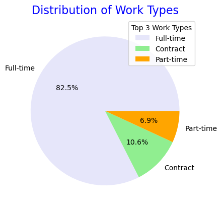

```python
# @title Distribution of Work Types
# Count occurrences of each unique value in the 'formatted_work_type' column
work_type_counts = dataset1_new['formatted_work_type'].value_counts()

# Extract values and labels for the pie chart
values = work_type_counts.values
labels = work_type_counts.index

# Sort values and labels in descending order
sorted_indexes = sorted(range(len(values)), key=lambda i: values[i], reverse=True)
sorted_values = [values[i] for i in sorted_indexes]
sorted_labels = [labels[i] for i in sorted_indexes]

# Extract top 3 values and labels
top_3_values = sorted_values[:3]
top_3_labels = sorted_labels[:3]

# Create pie chart with only top 3 values and labels
plt.pie(top_3_values,
        labels=top_3_labels,
        autopct='%1.1f%%',
        colors=['Lavender', 'lightgreen', 'orange'],
        radius=1,
        textprops={"fontsize": 10})

# Set the title for the pie chart
plt.title("Distribution of Work Types", color="Blue", fontsize=16)

# Add legend
plt.legend(title="Top 3 Work Types", loc="upper right")

# Display the pie chart
plt.show()
```

**Implementation:** We believe LinkedIn Premium can show this pie chart for members who are seeking for employment. For example, if a Premium member is looking for an Internship for a specific role, LinkedIn can show the percentage on pie chart and give members the option of choosing different employment types.

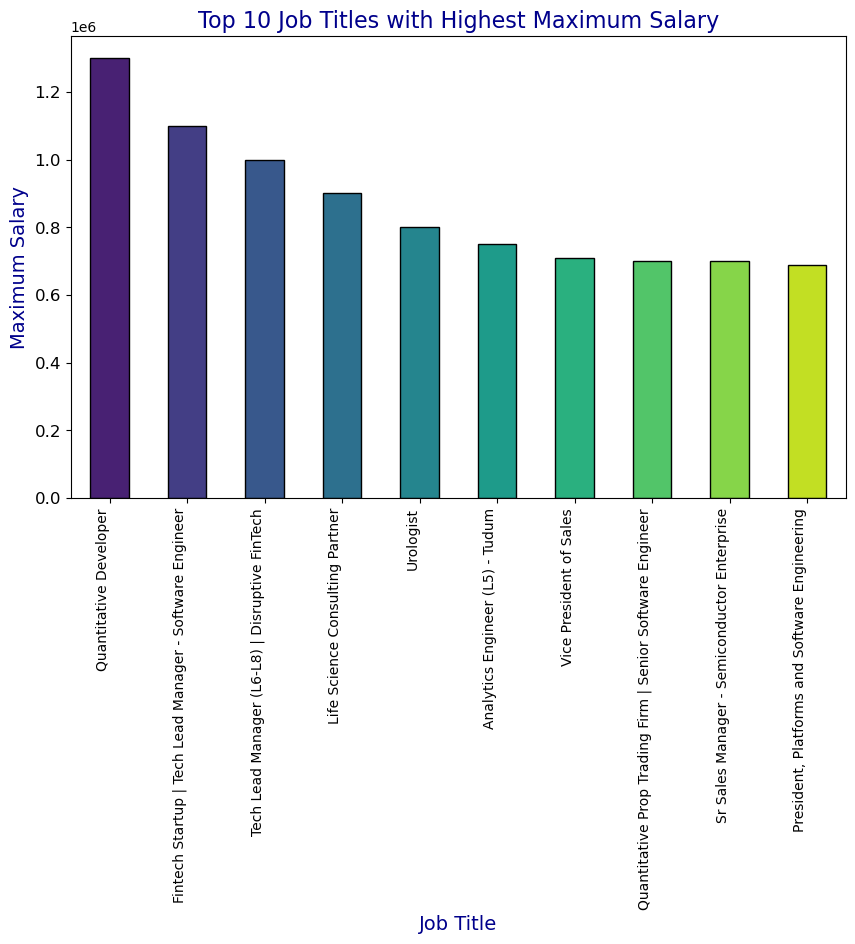

```python
# @title Top 10 Job Titles with Highest Maximum Salary

# We will group the job title with the max salary
job_title_max_salaries = dataset1_new.groupby('title')['max_salary'].max()

# Sort the salary in descending order so that we can get the top 10 values
job_title_max_salaries_sorted = job_title_max_salaries.sort_values(ascending=False)

# Save our top 10 salaries in dataset
top_10_max_salaries = job_title_max_salaries_sorted.head(10)

# Set a Seaborn color palette with virdis
colors = sns.color_palette('viridis', n_colors=len(top_10_max_salaries))

# Create a bar chart with imported colors
plt.figure(figsize=(10, 6))
top_10_max_salaries.plot(kind='bar', color=colors, edgecolor='black')

plt.title('Top 10 Job Titles with Highest Maximum Salary', fontsize=16, color='darkblue')
plt.xlabel('Job Title', fontsize=14, color='darkblue')
plt.ylabel('Maximum Salary', fontsize=14, color='darkblue')
plt.xticks(rotation=90, ha='right', fontsize=10)
plt.yticks(fontsize=12)
plt.show()
```

According to this bar chart, we can see that the top 3 highest salary goes to Tech-related jobs.

**Implementation:** For example, when members applies for jobs, LinkedIn can provide a comprehensive page for these members that show the maximum salary, minimum salary, and maybe average salary for different job titles.

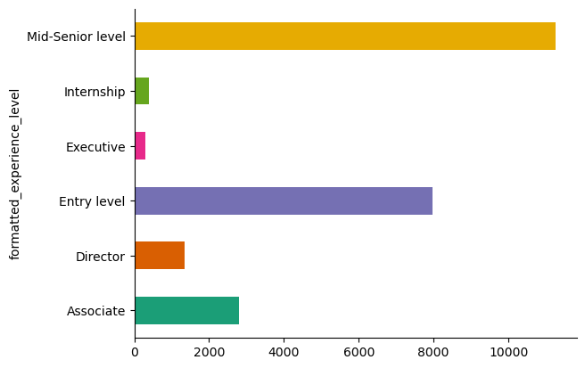

```python
# @title Bar graph of Experience Level Required

from matplotlib import pyplot as plt
import seaborn as sns
dataset1_new.groupby('formatted_experience_level').size().plot(kind='barh', color=sns.palettes.mpl_palette('Dark2'))
plt.gca().spines[['top', 'right',]].set_visible(False)
```

According to this bar chart, we can see that the most companies are looking for applicants who have Mid-Senior level of experience which usually is from 4-6 years, and then Entry level from 0-3 years.

**Implementation:** When LinkedIn Premium member look at their different job titles, they can see the experience level distribution for that specific job to compare their own profile or experience level.

### **DATA ANALYSIS - DATASET 1**

We provide the correlation matrix for the numerical columns in this dataset as below:

```
Correlation Matrix:
                   views   applies  remote_allowed  sponsored  max_salary  \
views           1.000000  0.881513        0.341144   0.052911    0.099336
applies         0.881513  1.000000        0.296061   0.017668    0.041933
remote_allowed  0.341144  0.296061        1.000000  -0.082741    0.127098
sponsored       0.052911  0.017668       -0.082741   1.000000   -0.016326
max_salary      0.099336  0.041933        0.127098  -0.016326    1.000000
min_salary      0.117235  0.055115        0.104746   0.013862    0.922487

                min_salary
views             0.117235
applies           0.055115
remote_allowed    0.104746
sponsored         0.013862
max_salary        0.922487
min_salary        1.000000
```

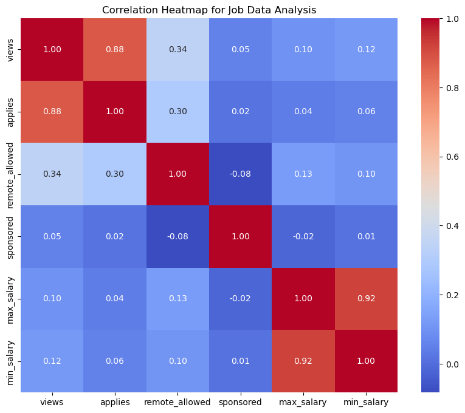

```python
# @title Correlation Heatmap for Job Data Analysis
# Select relevant numeric columns for heatmap analysis
heatmap_data = dataset1_new[['views', 'applies', 'remote_allowed', 'sponsored', 'max_salary', 'min_salary']]

# Calculate the correlation matrix
corr_matrix = heatmap_data.corr()

# Display the correlation matrix
print("Correlation Matrix:")
print(corr_matrix)

# Visualize correlation matrix using a heatmap
plt.figure(figsize=(10, 8))
sns.heatmap(corr_matrix, annot=True, cmap='coolwarm', fmt=".2f", annot_kws={"size": 10})
plt.title('Correlation Heatmap for Job Data Analysis')
plt.show()
```

The heatmap illustrates the correlation coefficients between different numeric features. A correlation coefficient close to 1 indicates a strong positive correlation, while a coefficient close to -1 indicates a strong negative correlation. From the heatmap, we observe that:

- Views and Applies have a strong positive correlation of approximately 0.88, indicating that job postings with higher views tend to receive more applications.
- Views and Remote Allowed have a moderate positive correlation of approximately 0.34, suggesting that job postings with remote work allowance may attract more views.
- Applies and Remote Allowed also show a moderate positive correlation, indicating that job postings with remote work allowance may receive more applications.
- There are almost no correlation between Views, Applies, Remote_allowed and Sponsored, Max_salary, and Min_salary.
- There is a strong positive correlation between Min_salary and Max_salary, we believe this is because if maximum salary increases, minimum salary will also increase.

### **DATA EXPLORATION - DATASET 2**

Next, we will look at our second dataset on Linkedin Profiles and Data and explore this together.

```python
# Load the dataset
dataset2 = pd.read_csv("C:/Users/anhta/OneDrive/Desktop/MSBA 265/Project/dump.csv")

# Display the first few rows of the dataset
dataset2.head(5)
```

|  | Unnamed: 0 | ageEstimate | companyFollowerCount | companyHasLogo | companyName | companyStaffCount | companyUrl | companyUrn | connectionsCount | country | ... | mbrLocationCode | mbrTitle | memberUrn | posLocation | posLocationCode | posTitle | positionId | startDate | avgMemberPosDuration | avgCompanyPosDuration |
| --- | --- | --- | --- | --- | --- | --- | --- | --- | --- | --- | --- | --- | --- | --- | --- | --- | --- | --- | --- | --- | --- |
| 0 | 0 | 41.0 | 198859.0 | 5a92c12e-0a20-482b-95ec-e705a6294730-2.png | Commonwealth Bank | 32905.0 | http://www.commbank.com.au/ | urn:li:company:2848 | 500.0 | au | ... | urn:li:fs_region:(au,4910) | Portfolio Executive at Commonwealth Bank | urn:li:member:10013136 | NaN | NaN | Portfolio Executive | 240345.0 | 2014-07-01 | 760.5000 | 989.9361 |
| 1 | 1 | 41.0 | 198859.0 | 5a92c12e-0a20-482b-95ec-e705a6294730-2.png | Commonwealth Bank | 32905.0 | http://www.commbank.com.au/ | urn:li:company:2848 | 500.0 | au | ... | urn:li:fs_region:(au,4910) | Portfolio Executive at Commonwealth Bank | urn:li:member:10013136 | Sydney, Australia | urn:li:fs_region:(au,4910) | Solution Delivery Executive | 240346.0 | 2013-11-01 | 760.5000 | 989.9361 |
| 2 | 2 | 41.0 | 10047.0 | b1c3fd9a-8f21-48f8-8321-d773b1ff3cb7-2.png | CommSec | 619.0 | http://www.commsec.com.au | urn:li:company:2851 | 500.0 | au | ... | urn:li:fs_region:(au,4910) | Portfolio Executive at Commonwealth Bank | urn:li:member:10013136 | NaN | NaN | Project Manager | 240348.0 | 2008-08-01 | 760.5000 | 747.2308 |
| 3 | 3 | 41.0 | 198859.0 | 5a92c12e-0a20-482b-95ec-e705a6294730-2.png | Commonwealth Bank | 32905.0 | http://www.commbank.com.au/ | urn:li:company:2848 | 500.0 | au | ... | urn:li:fs_region:(au,4910) | Portfolio Executive at Commonwealth Bank | urn:li:member:10013136 | NaN | NaN | Project Manager | 240350.0 | 2007-02-01 | 760.5000 | 989.9361 |
| 4 | 4 | 30.0 | 300723.0 | 0f982557-a907-409e-af20-1feb0e0813cd-2.png | PayPal | 22522.0 | http://www.paypal.com | urn:li:company:1482 | 500.0 | au | ... | urn:li:fs_region:(au,4910) | Senior Marketing Manager, PayPal | urn:li:member:100186032 | NaN | NaN | Senior Marketing Manager | 229893.0 | 2017-01-01 | 395.2857 | 683.3496 |

5 rows × 27 columns

```python
# Checking the column's information as well as Non-Null Count
dataset2.info()
```

```
<class 'pandas.core.frame.DataFrame'>
RangeIndex: 39537 entries, 0 to 39536
Data columns (total 27 columns):
 #   Column                 Non-Null Count  Dtype
---  ------                 --------------  -----
 0   Unnamed: 0             39537 non-null  int64
 1   ageEstimate            39537 non-null  float64
 2   companyFollowerCount   38071 non-null  float64
 3   companyHasLogo         36407 non-null  object
 4   companyName            39535 non-null  object
 5   companyStaffCount      38401 non-null  float64
 6   companyUrl             37449 non-null  object
 7   companyUrn             39537 non-null  object
 8   connectionsCount       39537 non-null  float64
 9   country                39537 non-null  object
```

[output cut: 19 more lines]

### **DATA PREPROCESSING - DATASET 2**

We will go through the same steps as Dataset 1, including cleaning up data, data transformation, removing null values and unnecessary columns.

We first remove the column `Unnamed: 0` because it is not a relevant data column:

```python
# Remove the column Unnamed: 0
dataset2 = dataset2.drop(dataset2.columns[0], axis=1)
```

Next, we will be changing the column names of the Dataset 2 for better analysis:

```python
# Define the new column names
new_column_names = {
    'ageEstimate': 'Age Estimate',
    'companyFollowerCount': 'Company Follower Count',
    'companyHasLogo': 'Company Has Logo',
    'companyName': 'Company Name',
    'companyStaffCount': 'Company Staff Count',
    'companyUrl': 'Company URL',
    'companyUrn': 'Company URN',
    'connectionsCount': 'Connections Count',
    'country': 'Country',
    'endDate': 'End Date',
    'followable': 'Followable',
    'followersCount': 'Followers Count',
    'genderEstimate': 'Gender Estimate',
    'hasPicture': 'Has Picture',
    'isPremium': 'Is Premium',
    'mbrLocation': 'Member Location',
    'mbrLocationCode': 'Member Location Code',
    'mbrTitle': 'Member Title',
    'memberUrn': 'Member URN',
    'posLocation': 'Position Location',
    'posLocationCode': 'Position Location Code',
    'posTitle': 'Position Title',
    'positionId': 'Position ID',
    'startDate': 'Start Date',
    'avgMemberPosDuration': 'Average Member Postion Duration',
    'avgCompanyPosDuration': 'Average Company Postion Duration'
}

# Rename columns inplace
dataset2.rename(columns=new_column_names, inplace=True)
```

Because there are 27 columns in this dataset, we believe to optimize the analysis and provide valuable insights, we will choose only the necessary columns:

```python
# Select important columns for analysis
important_columns = [
    'Age Estimate',
    'Company Follower Count',
    'Company Name',
    'Company Staff Count',
    'Connections Count',
    'Country',
    'Followable',
    'Followers Count',
    'Gender Estimate',
    'Is Premium',
    'Member Location',
    'Member Title',
    'Position Title',
    'Average Member Postion Duration',
    'Average Company Postion Duration']

# Keep only the important columns
dataset2 = dataset2[important_columns]
```

Next, we will check the number of Null values in Dataset 2 using a bar graph:

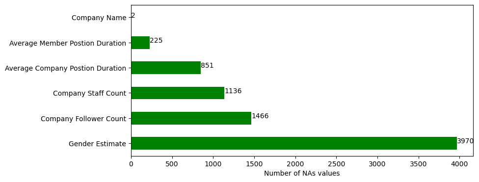

```python
def plot_nas(df: pd.DataFrame):
    if df.isnull().sum().sum() != 0:
        na_df = df.isnull().sum()
        na_df = na_df.drop(na_df[na_df == 0].index).sort_values(ascending=False)
        missing_data = pd.DataFrame({'Missing Ratio %' :na_df})
        missing_data.plot(kind="barh", legend=False, color = 'green')  # Specify plot type
        plt.xlabel('Number of NAs values')  # Add label for y-axis

        for index, value in enumerate(na_df):
            plt.text(value, index, str(value))  # Show number for each bar

        plt.show()
    else:
        print('No NAs found')

plot_width, plot_height = (9,4) # Adjusting plot figures
plt.rcParams['figure.figsize'] = (plot_width,plot_height)

plot_nas(dataset2)
```

```python
# Removing all null values
dataset2_new = dataset2.dropna()

# Removing all potential duplicates
dataset2_new = dataset2_new.drop_duplicates()

# Viewing our data info after removing null values
dataset2_new.info()
```

```
<class 'pandas.core.frame.DataFrame'>
Int64Index: 33039 entries, 0 to 39536
Data columns (total 15 columns):
 #   Column                            Non-Null Count  Dtype
---  ------                            --------------  -----
 0   Age Estimate                      33039 non-null  float64
 1   Company Follower Count            33039 non-null  float64
 2   Company Name                      33039 non-null  object
 3   Company Staff Count               33039 non-null  float64
 4   Connections Count                 33039 non-null  float64
 5   Country                           33039 non-null  object
 6   Followable                        33039 non-null  float64
 7   Followers Count                   33039 non-null  float64
 8   Gender Estimate                   33039 non-null  object
 9   Is Premium                        33039 non-null  float64
 10  Member Location                   33039 non-null  object
 11  Member Title                      33039 non-null  object
 12  Position Title                    33039 non-null  object
 13  Average Member Postion Duration   33039 non-null  float64
 14  Average Company Postion Duration  33039 non-null  float64
dtypes: float64(9), object(6)
memory usage: 4.0+ MB
```

```python
# View our dataset 2 after cleaning
dataset2.head(5)
```

|  | Age Estimate | Company Follower Count | Company Name | Company Staff Count | Connections Count | Country | Followable | Followers Count | Gender Estimate | Is Premium | Member Location | Member Title | Position Title | Average Member Postion Duration | Average Company Postion Duration |
| --- | --- | --- | --- | --- | --- | --- | --- | --- | --- | --- | --- | --- | --- | --- | --- |
| 0 | 41.0 | 198859.0 | Commonwealth Bank | 32905.0 | 500.0 | au | 1.0 | 506.0 | male | 0.0 | Sydney Area, Australia | Portfolio Executive at Commonwealth Bank | Portfolio Executive | 760.5000 | 989.9361 |
| 1 | 41.0 | 198859.0 | Commonwealth Bank | 32905.0 | 500.0 | au | 1.0 | 506.0 | male | 0.0 | Sydney Area, Australia | Portfolio Executive at Commonwealth Bank | Solution Delivery Executive | 760.5000 | 989.9361 |
| 2 | 41.0 | 10047.0 | CommSec | 619.0 | 500.0 | au | 1.0 | 506.0 | male | 0.0 | Sydney Area, Australia | Portfolio Executive at Commonwealth Bank | Project Manager | 760.5000 | 747.2308 |
| 3 | 41.0 | 198859.0 | Commonwealth Bank | 32905.0 | 500.0 | au | 1.0 | 506.0 | male | 0.0 | Sydney Area, Australia | Portfolio Executive at Commonwealth Bank | Project Manager | 760.5000 | 989.9361 |
| 4 | 30.0 | 300723.0 | PayPal | 22522.0 | 500.0 | au | 1.0 | 951.0 | female | 0.0 | Sydney Area, Australia | Senior Marketing Manager, PayPal | Senior Marketing Manager | 395.2857 | 683.3496 |

```python
# Showing basic statistics for numeric columns
dataset2.describe().T
```

|  | count | mean | std | min | 25% | 50% | 75% | max |
| --- | --- | --- | --- | --- | --- | --- | --- | --- |
| Age Estimate | 39537.0 | 38.434251 | 9.626035 | 20.0 | 31.0000 | 38.0000 | 45.00000 | 86.0 |
| Company Follower Count | 38071.0 | 214173.072706 | 694228.797279 | 0.0 | 1490.0000 | 14331.0000 | 126361.00000 | 7502740.0 |
| Company Staff Count | 38401.0 | 20451.816177 | 67548.466022 | 0.0 | 97.0000 | 1270.0000 | 9808.00000 | 568533.0 |
| Connections Count | 39537.0 | 424.573159 | 123.317422 | 0.0 | 371.0000 | 500.0000 | 500.00000 | 500.0 |
| Followable | 39537.0 | 0.950199 | 0.217537 | 0.0 | 1.0000 | 1.0000 | 1.00000 | 1.0 |
| Followers Count | 39537.0 | 1203.336925 | 2976.006298 | 0.0 | 353.0000 | 654.0000 | 1191.00000 | 161922.0 |
| Is Premium | 39537.0 | 0.130359 | 0.336702 | 0.0 | 0.0000 | 0.0000 | 0.00000 | 1.0 |
| Average Member Postion Duration | 39312.0 | 875.186984 | 639.812201 | 0.0 | 502.1250 | 730.6000 | 1068.91965 | 15492.5 |
| Average Company Postion Duration | 38686.0 | 888.257529 | 331.099677 | -91.0 | 724.8613 | 897.0691 | 1039.16830 | 9497.0 |

We looked at some statistics for the numerical columns in Dataset 2. For example, for Age Estimate, we can see that the average age is ~38 years old. For Company Follower Count, the maximum value is 7,502,740 which is equivalent to 7 Millions followers.

### **DATA VISUALIZATION - DATASET 2**

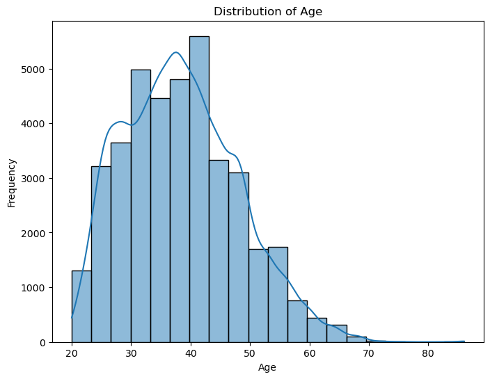

```python
# @title Distribution of LinkedIn Member's Age
plt.figure(figsize=(8, 6))
sns.histplot(dataset2['Age Estimate'], bins=20, kde=True)
plt.title('Distribution of Age')
plt.xlabel('Age')
plt.ylabel('Frequency')
plt.show()
```

This graph is the histogram to show the Age Distribution of all Linkedin members in our dataset. We can see here that most members are from 30 to 45 years old.

**Implementation:** LinkedIn Premium members can see the distribution of Age histogram when they check on who view their profiles.

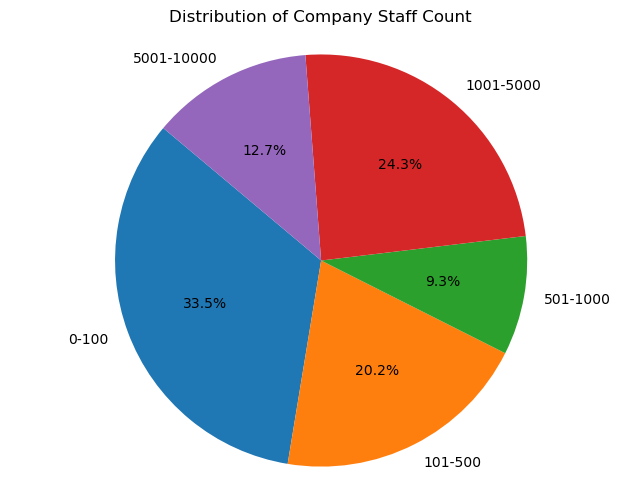

```python
# @title Distribution of Company Staff Count
# Define the ranges for grouping
group_ranges = [(0, 100), (101, 500), (501, 1000), (1001, 5000), (5001, 10000)]

# Group the data based on the defined ranges
group_counts = []
for range_min, range_max in group_ranges:
    count = dataset2[(dataset2['Company Staff Count'] >= range_min) & (dataset2['Company Staff Count'] <= range_max)].shape[0]
    group_counts.append(count)

# Define labels for the pie chart
labels = [f'{range_min}-{range_max}' for range_min, range_max in group_ranges]

# Plot the pie chart
plt.figure(figsize=(8, 6))
plt.pie(group_counts, labels=labels, autopct='%1.1f%%', startangle=140)
plt.title('Distribution of Company Staff Count')
plt.axis('equal')  # Equal aspect ratio ensures that pie is drawn as a circle.
plt.gca().axes.get_xaxis().set_visible(False)  # Hide the x-axis tick labels
plt.gca().axes.get_yaxis().set_visible(False)  # Hide the y-axis tick labels
plt.show()
```

For this pie chart, we divided all the companies 5 groups:

1. Companies with 0-100 employees
2. Companies with 101-500 employees
3. Companies with 501-1000 employees
4. Companies with 1001-5000 employees
5. Companies with 5001-10000 employees

**Implementation:** LinkedIn can consider using this for Premium members who are applying for jobs. On an average, usually a person applies to at least 10 to 100 jobs, so to have this visualization, members can know what their ideal company's size is based on their job applications.

### **DATA ANALYSIS - DATASET 2**

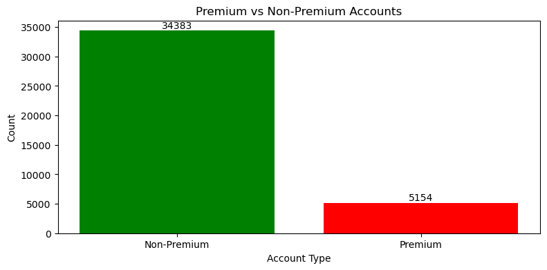

```python
# @title Comparison between Number of Premium Members vs NonPremium
# Count the occurrences of premium and non-premium accounts
premium_counts = dataset2['Is Premium'].value_counts()

# Plotting the counts
plt.bar(premium_counts.index, premium_counts.values, color=['green', 'red'])

# Adding text labels on top of each bar
for i, count in enumerate(premium_counts.values):
    plt.text(i, count, str(count), ha='center', va='bottom', fontsize=10)

plt.xticks([0, 1], ['Non-Premium', 'Premium'])
plt.title('Premium vs Non-Premium Accounts')
plt.xlabel('Account Type')
plt.ylabel('Count')
plt.show()
```

Here, we can see that there are more than 34,000 profiles that are normal accounts compared to only 5,000 Premium accounts. Rather than using this for Premium members, we would like to recommend LinkedIn to use this for their own analysis on their membership growth.

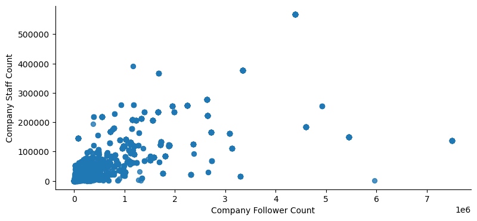

```python
# @title Scatter Chart for Company Follower Count vs Company Staff Count

dataset2.plot(kind='scatter', x='Company Follower Count', y='Company Staff Count', s=32, alpha=.8)
plt.gca().spines[['top', 'right',]].set_visible(False)
```

We can see that most companies have less than 10,000 staff. Also, based on our graph here, the more followers a company has, the higher the count for company's staff. So the possibility that if you see a company with a lot of followers, it could mean that the company's size is big and they have a lot of staff.

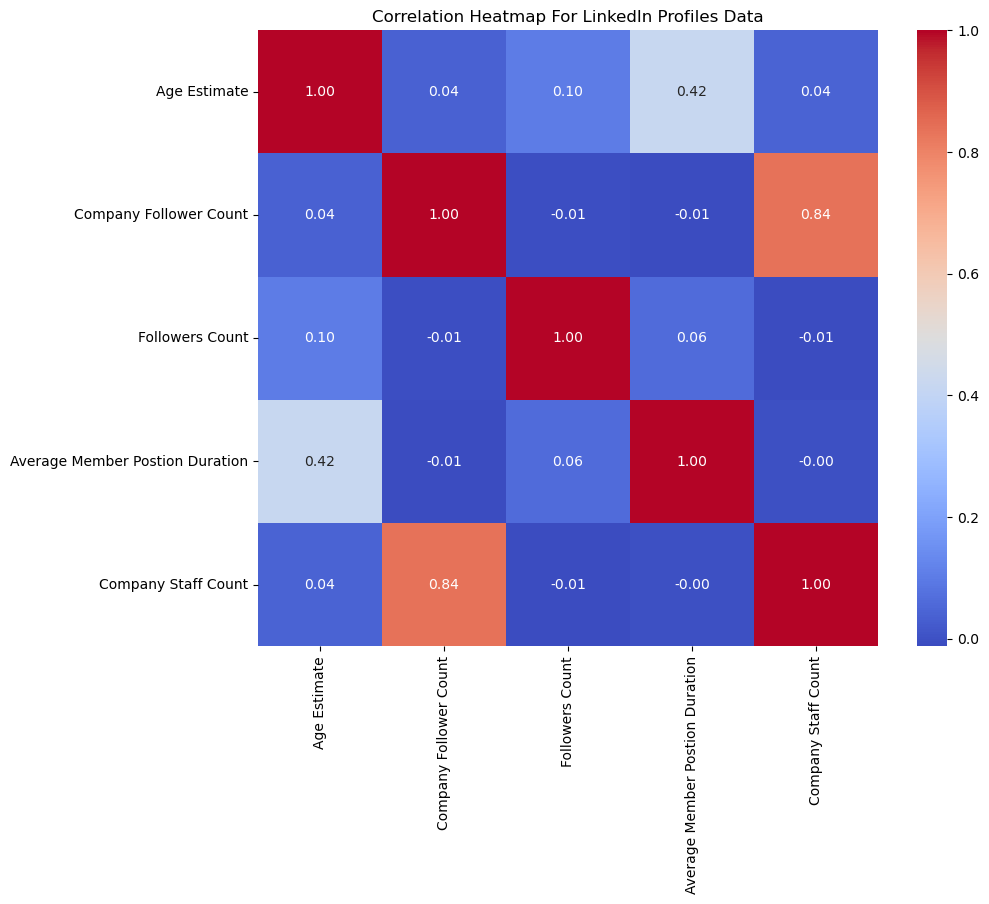

```python
# @title Correlation Heatmap for LinkedIn Profiles
# Select relevant numeric columns for correlation analysis
numeric_columns = dataset2[['Age Estimate', 'Company Follower Count', 'Followers Count',
                      'Average Member Postion Duration', 'Company Staff Count']]

# Calculate the correlation matrix
corr_matrix = numeric_columns.corr()

# Visualize correlation matrix using a heatmap
plt.figure(figsize=(10, 8))
sns.heatmap(corr_matrix, annot=True, cmap='coolwarm', fmt=".2f", annot_kws={"size": 10})
plt.title('Correlation Heatmap For LinkedIn Profiles Data')
plt.show()
```

Similar to the first dataset, we also made a correlation matrix heat map to show case the relationship between numerical columns. However, unlike the first dataset where there were some strong relationships, in this dataset, there is only a strong positive relationship between Company Staff Count and Company Follower Count.

### **INSIGHTS SUMMARY**

The insights below provide answers to the initial project objectives for this proposal:

1. In the first dataset, 'LinkedIn Job Postings - 2023', we focus a lot on analyzing Job Postings on LinkedIn and found that most jobs on LinkedIn are for Full-time position.
2. The top 3 highest salary are all related to Tech jobs, and all over $100,000.
3. Most jobs on LinkedIn are for Med-Senior level and Entry level.
4. The average age for LinkedIn members is 38, and most members are around 30 to 45 years old.
5. A lot of companies on LinkedIn have less than 100 staff, meaning that companies are using the platform to reach more people.

### **RECOMMENDATIONS & IMPLEMENTATIONS**

In reality, there are a lot of Premium members who use LinkedIn solely for the statistical graphic that LinkedIn offers. We believe it is a great feature but of course, it could be improved in various aspects.

Our team worked on 2 different datasets because we want to give LinkedIn the most thorough analysis on Data exploration, visualization and analysis for Premium features. We provided different graphs above to give LinkedIn the options of choosing the most suitable ones to implement for their members.

For example, the pie chart on dataset 2 can be used to show members their ideal company's size based on their job applications. Or the pie chart in dataset 1 is good to show what work types are available for a specific type of job title.

### **MILESTONE 1 CONCLUSION**

We successfully concluded Milestone 1. We hope LinkedIn can use our report to make careful decision on upgrading their LinkedIn Premium features. With better visualization on statistics, we strongly believe it will definitely attract more members to sign up for the Premium accounts.

For Milestone 2, we aim to go deeper into visualization and might carefully consider other aspects such as LinkedIn's financial performance for cost-related analysis. In Milestone 2, we might choose only one dataset to exclusively work with for a more thorough analysis.